# 📊 Data Sources

This study draws on multiple national datasets to estimate and explore gender disparities in death registration in India. Below are the key data sources used.

## 📁 Civil Registration System (CRS)

- Provides annual data on **registered deaths by sex and state**.
- Data span from **2014 to 2021**.
- Used to assess official registration coverage.

🔗 [Access CRS Reports (2014–2021)](https://censusindia.gov.in/census.website/data/VSREPORT)

## 📈 Sample Registration System (SRS)

- Supplies **age- and sex-specific death rates** for major Indian states.
- Used to estimate **expected number of deaths**.

🔗 [Access SRS Statistical Reports](https://censusindia.gov.in/census.website/data/SRSSTAT)

## 🧮 Population Projections

- Provides **projected population** by age and sex at the state level.
- Based on **Census 2011** and used to scale mortality estimates.

🔗 [National Population Projections Report (2011–2036)](https://nhm.gov.in/New_Updates_2018/Report_Population_Projection_2019.pdf)

## 📚 National Family Health Survey (NFHS)

### 🏢 State-Level Data

- Data on **female ownership of assets (land/house)** and **education**.
- From:
  - [NFHS-4 Report (2015–16)](https://rchiips.org/NFHS/nfhs-4Reports/India.pdf)
  - [NFHS-5 Factsheets (2019–21)](https://rchiips.org/nfhs/factsheet_NFHS-5.shtml)

### 🌍 District-Level Microdata (NFHS-5)

- Used to estimate **district-level death registration completeness**.
- Based on household responses about recent deaths and registration status.

🔗 [NFHS-5 Datasets – DHS Program](https://dhsprogram.com/data/dataset/India_Standard-DHS_2020.cfm)  
*🛡️ Access requires registration and approval from DHS.*

# 🧪 Methods

## 🧾 How We Estimated Completeness of Death Registration (2014–2021) for Bigger States

The **completeness of death registration** was defined as:

$$\text{Completeness} = \left( \frac{\text{Registered deaths (CRS)}}{\text{Estimated deaths (SRS)}} \right) \times 100$$

To calculate the *expected number of deaths* (denominator), we followed these steps:

### 🔢 Step-by-step Estimation of Expected Deaths

1. **Interpolated Population by Age and Sex**  
   We used official population projections for **2011, 2016, and 2021**, interpolating values for the intervening years (2014–2021) for each state and age-sex group.
2. **Applied Age-Specific Death Rates (ASDR)**  
   We multiplied SRS-reported **ASDRs** with the interpolated populations for each group.
3. **Summed Across Age Groups**  
   Expected deaths were calculated as:  
   ∑ *(Population in age group × ASDR for that group)*

### ⚠️ Handling Missing Data: Gujarat, 2015–2016

Sex-specific CRS data were unavailable for Gujarat in 2015 and 2016.  
To address this:

- We extracted **male–female death proportions** from **2014 and 2017**,
- Then **interpolated** the values for 2015 and 2016,
- And finally **distributed the total deaths** accordingly.

## 🧠 Estimating District-Level Completeness (2021)

We used a **Bayesian hierarchical logistic regression** model to estimate the probability of death registration using `ulam` from the **rethinking** package. The model included varying intercepts by gender, district, and state, and fixed effects for household asset ownership, religion, wealth, caste, and education.

**📐 Model Equation**

$$\begin{aligned}
\text{reg}_{g,d,s} &\sim \text{Binomial}(\text{death}_{g,d,s},\; p_{g,d,s}) \\[1ex]
\text{logit}(p_{g,d,s}) &= \alpha_{g} + \beta_{d} + \gamma_{s} \\
&\quad + b_{\text{own}} \cdot \text{ownership}_{g,d,s} + b_{\text{hindu}} \cdot \text{hindu}_{d,s} + b_{\text{wealth}} \cdot \text{poor}_{d,s} \\
&\quad + b_{\text{gen}} \cdot \text{gen}_{d,s} + b_{\text{edu}} \cdot \text{edu}_{g,d,s} \\[1.5ex]
\alpha_{g} &\sim \mathcal{N}(0,\; 1.5), \quad g \in \{1,2\} \\
\beta_{d} &\sim \mathcal{N}(0,\; 1), \quad d = 1,\dots,707 \\
\gamma_{s} &\sim \mathcal{N}(0,\; 1), \quad s = 1,\dots,36 \\
b_* &\sim \mathcal{N}(0,\; 1)
\end{aligned}$$

**Where:**

- $\text{reg}_{g,d,s}$ = Registered deaths for gender $g$, district $d$, state $s$
- $\text{death}_{g,d,s}$ = Total deaths (binomial denominator)
- $p_{g,d,s}$ = Probability of a death being registered
- $\alpha_{g}$ = Varying intercept by gender
- $\beta_{d}$ = Varying intercept by district
- $\gamma_{s}$ = Varying intercept by state
- $b_{\text{own}}$ = Effect of ownership (land/house)
- $b_{\text{hindu}}$ = Effect of religion (Percent of Hindu)
- $b_{\text{wealth}}$ = Effect of poverty (Percent of Poor)
- $b_{\text{gen}}$ = Effect of caste (Percent of General)
- $b_{\text{edu}}$ = Effect of education (median years)

**💻 Model Code**

**Show R code**

```r
library(tidyverse)
library(here)
library(rethinking)
library(bayesplot)

df <- read_rds(here("data", "death_reg.rds"))

district_id_df <- df |>
  ungroup() |>
  select(hv024, shdist) |>
  distinct() |>
  mutate(district_id = row_number())

state_id_df <-  df |>
  ungroup() |>
  select(hv024) |>
  distinct() |>
  mutate(state_id = row_number())

df <- df |>
  left_join(state_id_df) |>
  left_join(district_id_df)

df <- df |>
  mutate(gender_id = case_when(gender == "Male" ~ 1,
                               gender == "Female" ~ 2,
                               T ~ NA))

df |>
  ungroup() |>
  count(gender_id)

dat <- list(
  state = df$state_id,
  district = df$district_id,
  gender = df$gender_id,
  death = round(df$death, 0),
  reg = round(df$reg_death, 0),
  p = df$reg_per / 100,
  edu = df$edu,
  hindu = df$Hindu,
  poor = df$Poor,
  gen = df$General,
  ownership = df$ownership
)

# 1. Fit model (as specified)
m2020 <- ulam(
  alist(
    reg ~ dbinom(death, p),
    logit(p) <- a[gender] +
      b[district] + c[state] +
      b_own * ownership +
      b_hindu * hindu +
      b_wealth * poor +
      b_gen * gen +
      b_edu * edu,

    a[gender] ~ dnorm(0, 1.5),
    b[district] ~ dnorm(0, 1),
    c[state] ~ dnorm(0, 1),

    b_hindu ~ dnorm(0, 1),
    b_wealth ~ dnorm(0, 1),
    b_gen ~ dnorm(0, 1),
    b_own ~ dnorm(0, 1),
    b_edu ~ dnorm(0, 1)
  ),
  data = dat, chains = 4, cores = 4, log_lik = TRUE
)

prec <- precis(m2020, depth = 2)

post <- extract.samples(m2020)

###############################################
#======= Posterior Predictive Check============
###############################################

# data
y <- df$reg_per / 100         # Observed proportions (scaled to [0,1])
yrep <- post$p                # Posterior predictive samples (matrix: n_samples x 1414)


# Set parameters
chunk_size <- 500  # Number of districts per plot
n_total <- length(y)  # Total districts (1414)
n_chunks <- ceiling(n_total / chunk_size)

# Golden ratio dimensions (width = height * φ)
plot_height <- 10  # inches
plot_width <- round(plot_height * (1 + sqrt(5))/2, 1)  # ≈16.2 inches

# Create output directory
output_dir <- here("output", "ppc_gender_plots")
if (!dir.exists(output_dir)) dir.create(output_dir, recursive = TRUE)

# Custom theme for consistent styling
ppc_theme <- theme_minimal(base_size = 12) +
  theme(
    axis.text.x = element_text(angle = 45, hjust = 1, size = 12),
    plot.title = element_text(face = "bold", size = 14),
    plot.subtitle = element_text(size = 11),
    panel.grid.minor = element_blank(),
    legend.position = "bottom"
  )

# Main plotting loop
for (i in 1:n_chunks) {
  # Get district indices for current chunk
  idx <- ((i - 1) * chunk_size + 1):min(i * chunk_size, n_total)

  # Create gender-labeled factor (1=Male, 2=Female)
  gender_factor <- factor(dat$gender[idx],
                          levels = c(1, 2),
                          labels = c("Male", "Female"))

  # Create the plot
  current_plot <- ppc_intervals_grouped(
    y = y[idx],
    yrep = yrep[, idx],
    group = gender_factor,
    prob = 0.8,        # 80% inner interval
    prob_outer = 0.95, # 95% outer interval
    size = 1.2,        # Line thickness
    fatten = 1.5       # Point size
  ) +
    labs(
      title = sprintf("Death Registration: Districts %d-%d", round(min(idx)/2, 0), round(max(idx)/2, 0)),
      subtitle = "Posterior Predictive Check by Gender",
      x = "Gender",
      y = "Proportion of Deaths Registered"
    ) +
    ylim(0, 1) +       # Fixed y-axis range
    scale_x_discrete(labels = c("Male", "Female")) +
    ppc_theme


  # Display plot
  print(current_plot)

  # Save plot with golden ratio dimensions
  ggsave(
    filename = here(output_dir, sprintf("ppc_gender_%03d_%04d-%04d.png",
                                        i, min(idx), max(idx))),
    plot = current_plot,
    width = plot_width,
    height = plot_height,
    dpi = 300,
    bg = "white"
  )

  # Progress message
  cat(sprintf("Saved plot %d/%d: Districts %d-%d\n",
              i, n_chunks, min(idx), max(idx)))
}

cat("\nAll plots saved to:", output_dir, "\n")


##################################
#==========Estimates==============
##################################


# Calculate predicted yrep = # Calculate predicted probability from logit components
calc_prob <- function(a, b, c, d, e, f, g, h) {
  plogis(a + b + c + d + e + f + g + h)
}


# 1. Prepare data with all IDs and covariates
analysis_df <- df %>%
  ungroup() |>
  janitor::clean_names() |>
  select(state_id, district_id, gender_id,
         hindu, poor, general, death, reg_death, ownership, edu) %>%
  rename(gen = general) |>
  drop_na()  # Remove rows with missing values

# Function to get covariates for a given district and gender
get_covariates <- function(district_id, state_id, gender_id) {
  analysis_df %>%
    filter(district_id == !!district_id, state_id == !!state_id, gender_id == !!gender_id) %>%
    summarise(
      hindu = mean(hindu, na.rm = TRUE),
      poor = mean(poor, na.rm = TRUE),
      gen = mean(gen, na.rm = TRUE),
      ownership = mean(ownership, na.rm = TRUE),
      edu = mean(edu, na.rm = TRUE)
    ) %>%
    as.list()
}

# Updated probability function
calc_prob <- function(a, b, c, d, e, f, g, h) {
  plogis(a + b + c + d + e + f + g + h)
}

# District-level estimates
district_effects <- map_dfr(unique(dat$district), function(d) {
  s <- unique(dat$state[dat$district == d])

  covariates_m <- get_covariates(d, s, gender_id = 1)
  covariates_f <- get_covariates(d, s, gender_id = 2)

  male_prob <- calc_prob(
    a = post$a[, 1],
    b = post$b[, d],
    c = post$c[, s],
    d = post$b_own * covariates_m$ownership,
    e = post$b_hindu * covariates_m$hindu ,
    f = post$b_wealth * covariates_m$poor,
    g = post$b_gen * covariates_m$gen ,
    h = post$b_edu * covariates_m$edu
  )

  female_prob <- calc_prob(
    a = post$a[, 2],
    b = post$b[, d],
    c = post$c[, s],
    d = post$b_own * covariates_f$ownership,
    e = post$b_hindu * covariates_f$hindu ,
    f = post$b_wealth * covariates_f$poor,
    g = post$b_gen * covariates_f$gen ,
    h = post$b_edu * covariates_f$edu
  )

  tibble(
    district_id = d,
    male_est = mean(male_prob),
    male_lower = quantile(male_prob, 0.05),
    male_upper = quantile(male_prob, 0.95),

    female_est = mean(female_prob),
    female_lower = quantile(female_prob, 0.05),
    female_upper = quantile(female_prob, 0.95),

    diff_est = mean(male_prob - female_prob),
    diff_lower = quantile(male_prob - female_prob, 0.05),
    diff_upper = quantile(male_prob - female_prob, 0.95)
  )
})

# State-level estimates
state_effects <- map_dfr(unique(dat$state), function(s) {
  districts_in_state <- unique(dat$district[dat$state == s])

  district_probs <- map_dfr(districts_in_state, function(d) {
    covariates_m <- get_covariates(d, s, gender_id = 1)
    covariates_f <- get_covariates(d, s, gender_id = 2)

    male_prob <- calc_prob(
      a = post$a[, 1],
      b = post$b[, d],
      c = post$c[, s],
      d = post$b_own * covariates_m$ownership,
      e = post$b_hindu * covariates_m$hindu ,
      f = post$b_wealth * covariates_m$poor,
      g = post$b_gen * covariates_m$gen ,
      h = post$b_edu * covariates_m$edu
    )

    female_prob <- calc_prob(
      a = post$a[, 2],
      b = post$b[, d],
      c = post$c[, s],
      d = post$b_own * covariates_f$ownership,
      e = post$b_hindu * covariates_f$hindu ,
      f = post$b_wealth * covariates_f$poor,
      g = post$b_gen * covariates_f$gen ,
      h = post$b_edu * covariates_f$edu
    )

    tibble(
      male = male_prob,
      female = female_prob
    )
  }, .id = "district_id")

  male_state <- rowMeans(matrix(district_probs$male, nrow = nrow(post$a)))
  female_state <- rowMeans(matrix(district_probs$female, nrow = nrow(post$a)))

  tibble(
    state_id = s,
    male_est = mean(male_state),
    male_lower = quantile(male_state, 0.05),
    male_upper = quantile(male_state, 0.95),

    female_est = mean(female_state),
    female_lower = quantile(female_state, 0.05),
    female_upper = quantile(female_state, 0.95),

    diff_est = mean(male_state - female_state),
    diff_lower = quantile(male_state - female_state, 0.05),
    diff_upper = quantile(male_state - female_state, 0.95)
  )
})

# National-level estimate
national_effects <- {
  all_districts <- unique(dat$district)

  national_probs <- map_dfr(all_districts, function(d) {
    s <- unique(dat$state[dat$district == d])

    covariates_m <- get_covariates(d, s, gender_id = 1)
    covariates_f <- get_covariates(d, s, gender_id = 2)

    male_prob <- calc_prob(
      a = post$a[, 1],
      b = post$b[, d],
      c = post$c[, s],
      d = post$b_own * covariates_m$ownership,
      e = post$b_hindu * covariates_m$hindu ,
      f = post$b_wealth * covariates_m$poor,
      g = post$b_gen * covariates_m$gen ,
      h = post$b_edu * covariates_m$edu
    )

    female_prob <- calc_prob(
      a = post$a[, 2],
      b = post$b[, d],
      c = post$c[, s],
      d = post$b_own * covariates_f$ownership,
      e = post$b_hindu * covariates_f$hindu ,
      f = post$b_wealth * covariates_f$poor,
      g = post$b_gen * covariates_f$gen ,
      h = post$b_edu * covariates_f$edu
    )

    tibble(
      male = male_prob,
      female = female_prob
    )
  }, .id = "district_id")

  male_nat <- rowMeans(matrix(national_probs$male, nrow = nrow(post$a)))
  female_nat <- rowMeans(matrix(national_probs$female, nrow = nrow(post$a)))

  tibble(
    level = "national",
    male_est = mean(male_nat),
    male_lower = quantile(male_nat, 0.05),
    male_upper = quantile(male_nat, 0.95),

    female_est = mean(female_nat),
    female_lower = quantile(female_nat, 0.05),
    female_upper = quantile(female_nat, 0.95),

    diff_est = mean(male_nat - female_nat),
    diff_lower = quantile(male_nat - female_nat, 0.05),
    diff_upper = quantile(male_nat - female_nat, 0.95)
  )
}

writexl::write_xlsx(national_effects, here("output", "national_direct_effect_nfhs5.xlsx"))

writexl::write_xlsx(state_effects, here("output", "state_direct_effect_nfhs5.xlsx"))

writexl::write_xlsx(district_effects, here("output", "district_direct_effect_nfhs5.xlsx"))
```

## 🔍 Exploring Gender Disparities and Mediation by Ownership

### 🧭 Directed Acyclic Graph (DAG)

We constructed a DAG to represent our hypothesised pathways. Gender (exposure) affects death registration (outcome) both directly and indirectly through ownership of assets (mediator). Education and state were included as confounders.

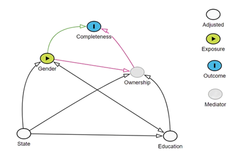

Figure 1. Directed Acyclic Graph Describing the Gender Effect on Completeness of Death Registration.

### 📑 Variable Definitions

- **Completeness**: % of expected deaths reported (based on SRS and CRS)
- **Ownership**: Average of % women owning land and % women owning houses (from NFHS-4 and NFHS-5)
- **Education**: Median years of schooling among women (state-level, NFHS)

### 🧮 Statistical Model

We fitted two Bayesian models (for 2015 and 2020) to estimate: - Total effect of gender (adjusted for education, state) - Direct effect of gender (additionally adjusted for ownership)

**🟠 Total Effect**

$$\begin{align*}
O_{i,g} &\sim \text{Binomial}(E_{i,g}, p_{i,g}) \\
\text{logit}(p_{i,g}) &= a[g] + b[\text{state}] + c \cdot \text{education}_{i} \\[1.5ex]
a[g] &\sim \text{Normal}(\bar{a}, \sigma) \\
\bar{a} &\sim \text{Normal}(0, 1.5) \\
\sigma &\sim \text{Exponential}(3) \\
b[\text{state}] &\sim \text{Normal}(0, 0.1) \\
c &\sim \text{Normal}(0, 0.1)
\end{align*}$$

**Where:**

- $O_{i,g}$: Number of registered deaths for group $g$ in state $i$
- $E_{i,g}$: Expected number of deaths for group $g$ in state $i$
- $p_{i,g}$: Probability of death registration for group $g$ in state $i$
- $g$: Gender group (male or female)
- $a[g]$: Gender-specific intercept
- $b[\text{state}]$: State-level random effect
- $\text{education}_{i}$: Median years of education among women in state $i$
- $c, d$: Coefficients for education and ownership, respectively

**🟣 Direct Effect (adjusting for ownership)**

$$\begin{align*}
O_{i,g} &\sim \text{Binomial}(E_{i,g}, p_{i,g}) \\
\text{logit}(p_{i,g}) &= a[g] + b[\text{state}] + c \cdot \text{education}_{i} + d \cdot \text{ownership}_{i} \\[1.5ex]
a[g] &\sim \text{Normal}(\bar{a}, \sigma) \\
\bar{a} &\sim \text{Normal}(0, 1.5) \\
\sigma &\sim \text{Exponential}(3) \\
b[\text{state}] &\sim \text{Normal}(0, 0.1) \\
c &\sim \text{Normal}(0, 0.1) \\
d &\sim \text{Normal}(0, 0.05)
\end{align*}$$

**Where:**

- $O_{i,g}$: Number of registered deaths for group $g$ in state $i$
- $E_{i,g}$: Expected number of deaths for group $g$ in state $i$
- $p_{i,g}$: Probability of death registration for group $g$ in state $i$
- $g$: Gender group (male or female)
- $a[g]$: Gender-specific intercept
- $b[\text{state}]$: State-level random effect
- $\text{education}_{i}$: Median years of education among women in state $i$
- $\text{ownership}_{i}$: Proportion of women owning land or house in state $i$
- $c, d$: Coefficients for education and ownership, respectively